# **Introduction**

This Jupyter notebook is for the Single Cell RNA-Seq training course taking place at the University of Cambridge, Department of Chemistry in March 2020.

The course is split into four parts and is intended to be "hands on", so we encourage you to run the code as we go along. To consolidate your learning, we recommend you go home and play around with other data sets.

Thanks to the Satija lab for creating the Seurat package and associated tutorials, which we will be using in the following session [Satija Lab's Seurat pipeline tutorial](https://satijalab.org/seurat/v3.0/pbmc3k_tutorial.html).

*Pre-requisites: You should be able to understand what the following two code chunks are doing*

```r
a = 3
b = 2
print(a+b)
```

```
[1] 5
```

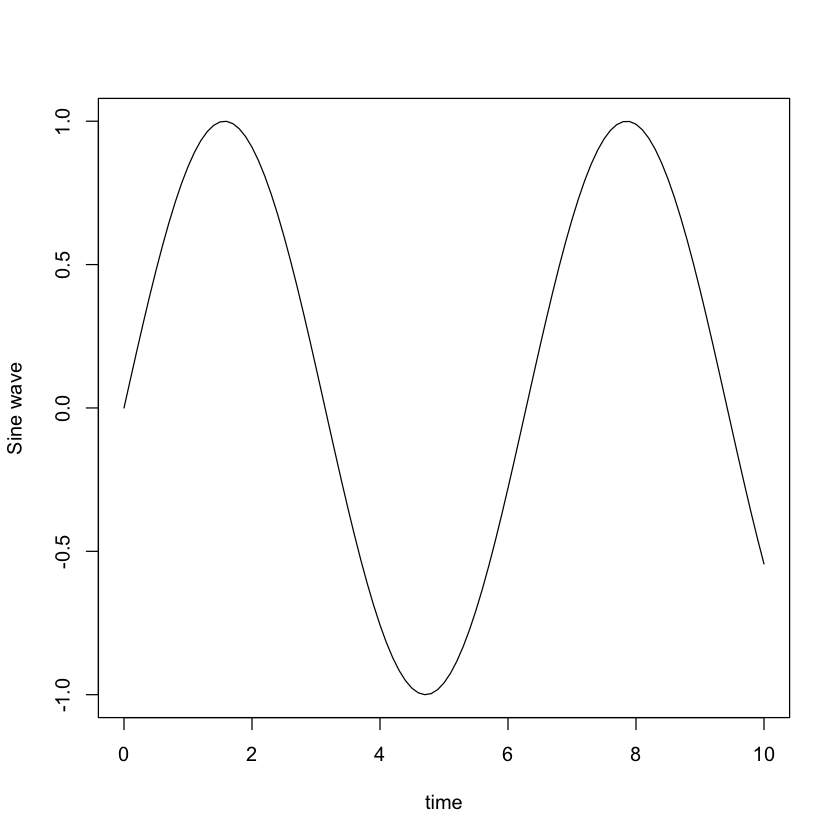

```r
t = seq(0,10,0.1)
y = sin(t)
plot(t,y,type="l", xlab="time", ylab="Sine wave")
```

To run the notebook locally, you will need to set up your system to run R in Jupyter notebooks.

1. Install Jupyter [using the following steps](https://jupyter.readthedocs.io/en/latest/install.html)
2. Install R [using the following steps](https://www.r-project.org/)
3. Start an interactive R session on the command line (**not RStudio!!**) and install some packages to set up an R kernel for Jupyter (see [this page](https://irkernel.github.io/installation))

```
# you will need to choose a CRAN mirror, doesn't matter which one
> install.packages(c('repr', 'IRdisplay', 'evaluate', 'crayon', 'pbdZMQ', 'devtools', 'uuid', 'digest'))

> devtools::install_github('IRkernel/IRkernel')

> IRkernel::installspec()
```

1. Create a conda environment using your terminal and activate it

```
$ conda create -n single_cell_R
$ conda activate single_cell_R
```

1. Install some R packages

```
# this may take a few minutes
$ conda install -c r r-essentials
```

1. Launch jupyter notebook and open the .ipynb file. There should be an 'R' logo in the top right corner.

```
$ jupyter notebook
```

# Lesson 1

### Introduction to single cell RNA-seq, setting up your R environment `

Before we do anything else, we need you to set up your R environment. This may take some time; we hope to go through some introductory information while we wait for everyone to get set up.

## **Setting up your environment**

This involves two things

1. Downloading the example data
2. Installing required packages

### **Data download**

For this tutorial, we will be analyzing a dataset containing gene expression data from peripheral blood mononuclear cells; this is freely available from 10X Genomics. In this experiment 2,700 cells were sequenced on the Illumina NextSeq 500.

Don't worry if you don't know what any of this means yet, we'll be covering it all during the course! For now, download the data using `download.file`

```r
dir.create("PBMC_Data")
dir <- "PBMC_Data"

url <- 'https://s3-us-west-2.amazonaws.com/10x.files/samples/cell/pbmc3k/pbmc3k_filtered_gene_bc_matrices.tar.gz'
file <- basename(url)
download.file(url, file)

untar(file, compressed = 'gzip', exdir = dir)
# you will get a warning saying untar(compressed=) is deprecated, ignore it
list.files(dir)
```

'filtered_gene_bc_matrices'

### **Install packages**

The packages you'll be needing for this course are dplyr, SingleR, Seurat and enrichR.

Run these commands one by one because there can be some difficulties.

If R asks you if you want to update packages, or install from source, say no.

This can take some time; we'll go through some background material while it installs

```r
start.time <- Sys.time()

install.packages("BiocManager") # package manager
install.packages('dplyr') # install dplyr - for easy table manipulation
install.packages('devtools')
# Seurat dependencies
BiocManager::install("multtest")
install.packages("mutoss")
install.packages("metap")
install.packages('Seurat') # install Seurat - for bulk of the analysis
install.packages('enrichR') # install enrichR - for pathway and process enrichment
devtools::install_github('dviraran/SingleR') # For cell type assignment

# check this worked by loading packages
library(SingleR)
library(dplyr)
library(enrichR)
library(Seurat)

end.time <- Sys.time()
time.taken <- end.time - start.time
print(time.taken)
```

```
Updating HTML index of packages in '.Library'
Making 'packages.html' ... done
```

## **What is transcriptomics?**

- Transcriptomics technologies measure the abundance of many different RNAs in a sample at once. Using this data, we can find differences in gene expression between samples.
- Measuring changes in gene expression allows us to link cell state and cell behaviour to molecular changes. This is a particularly useful method when the genes involved in a biological process are not previously known.
- Transcriptomic methods have been used for a wide variety of investigations including [cancer patient survival prediction](https://www.sciencedirect.com/science/article/pii/S0167947308002946), [understanding the mechanism of action of drugs](https://www.ncbi.nlm.nih.gov/pubmed/19183001) and [predicting compound-induced toxicity](https://www.ncbi.nlm.nih.gov/pubmed/29917034) .
- Transcriptomics was primarily done by microarray until the late 2000s; RNA-seq methods have now become dominant. These involve the synthesis of the cDNA for each transcript followed by high-throughput DNA sequencing.
- RNA-seq has greater depth and finer resolution than microarray-based methods. Additionally, and most importantly for our discussion today, it can be performed starting with tiny initial samples (picogram size). This key advantage is behind the astonishing development of single-cell transcriptomics methods over the last decade.

## **Single cell vs. Bulk RNA-seq**

[output not shown]

- Bulk tissue RNA sequencing measures the overall abundance of transcripts in tissue samples. For most applications, total RNA is extracted from tissue and enrichment for mRNA is performed using polyT beads. Typically, tissue samples from treatment and control are labelled with barcodes and sequenced in tandem; this avoids batch effects in the sequencing steps.
- This is a powerful method for understanding gene expression. However, tissues are known to consist of many different interacting cell types; these often have dramatically different gene expression patterns. In bulk tissue RNA-seq, the gene expression of all these cells is 'averaged' across the tissue.
- A seminal paper for single cell RNA sequencing is [Tang *et al*'s 'mRNA-Seq whole-transcriptome analysis of a single cell' (2009)](https://www.ncbi.nlm.nih.gov/pubmed/19349980). We highly recommend that you give it a read!
- Single-cell RNA sequencing methods allow us to study cellular heterogeneity in tissues by separating individual cells before measuring mRNA abundance. While this is more costly than bulk tissue RNA-seq, it opens up many new biological questions for study. Applications include:
  - the identification of new cell subtypes
  - quantifying relative populations of cell types in bulk tissue
  - measuring the heterogeneity of cell responses to stimuli, and the stochasticity of gene expression
  - inference of gene regulatory networks across the cells
  - studying heterogeneity of tumour cells and their interactions with other cells in the tumour microenvironment

[output not shown]

The throughput of single cell experiments is rapidly expanding, as well as the depth of sequencing available. This increases the statistical power of results and enables the discovery of rarer cell types. Moreover, single-cell sequencing has matured into a commercially available technology available for use by domain experts. We hope that this course will enable you to get started working with single cell RNA sequencing data yourself.

## **Experimental workflow for single cell RNA-seq**

[figure not shown]

**Figure from Wikipedia**

What follows is a brief summary of experimental issues in the acquisition of single-cell RNA sequencing data in the form of a count matrix, particularly those that are significant for the bioinformatics analysis. We'll be focusing on the popular [10x Genomics](https://www.10xgenomics.com/) protocol because the data that we'll use later was generated with this technology. Most of the basic principles hold across technologies, and we'll mention when something is particularly 10x specific. If you want more information on experimental protocols, we recommend the following review paper: [Nguyen, 2018](https://www.frontiersin.org/articles/10.3389/fcell.2018.00108/full).

### **From tissue sample to sequencing library**

#### **Single cell isolation**

- The first step, common to most scRNA-seq methods, is to isolate the cell type of interest in suspension. This is relatively easy for some cell types such as immune cells, but much more challenging for tightly bound tissues. Typically the tissue is first dissected and minced; breakdown of the ECM is often performed with an enzyme such as trypsin.
- All preparation steps must be performed with care to avoid inducing changes in the gene expression of cells before they can be sequenced. Fixation strategies have been developed which can make this easier. It is also important to be aware of the bias induced by the differing ease of extraction between cell types.
- For tissues that cannot be easily dissociated, 'single-nuclei' methods have been developed which recover nuclei directly from bulk tissue.

#### **Cell type enrichment**

- To investigate cellular heterogeneity within known cell types, it is often desirable to isolate cells of a particular type prior to sequencing. This can be accomplished using FACS (fluoresence-activated cell-sorting) using fluorescent antibodies.

[output not shown]

#### **Capturing cells**

- The method for extracting and labelling the mRNA from individual cells is the main difference between scRNA-seq platforms. 10X Chromium is a microdroplet-based platform which can handle 1000s of cells; this is not the highest throughput avaiable, but it is relatively simple to perform and allows barcoding and sample multiplexing for robust quantification.
- Microfluidics is used to load the cells into droplets, together with beads; each droplet contains one gel bead and either no cell or only one cell. The gel beads are attached to oligos which enables synthesis of cDNA, starting from the capped 3' end of the mRNA. The oligos include:
  - A poly-dT sequence to capture mRNA
  - A randomised barcode or Unique Molecular Identifier: these are different for each transcript
  - A droplet-specific barcode: these are the same for each transcript in a droplet
  - A primer for Illumina sequencing

[output not shown]

#### **Reverse transcription to create cDNA**

Immediately after a GEM is formed the gel bead dissolves - releasing the primers as well as enzymes which lyse (break open) the cell to release mRNA transcripts, and importantly: *reverse transcription reagents*.

This initiates reverse transcription which generates full length, barcoded cDNA from the mRNA contained in the single cells. cDNA or complementary DNA is is DNA synthesised from a single strand of RNA. The reason we produce cDNA instead of leaving the mRNA as-is is because:

- DNA is more stable
- Allows for amplification (which uses DNA polymerases)
- Can leverage more mature DNA sequencing technology

A key development in single-cell RNA sequencing technology was the development of a template-switching mechanism which utilises a reverse transcriptase from Moloney murine leukemia virus. This adds a polyC tail to the 3' end of the synthesised cDNA, allowing it to be tagged with a primer for amplification.

[output not shown]

#### **cDNA amplification and library generation**

The cDNA is isolated from the solution of reagents and oil and amplified by PCR to create a sequencing library. This is simply a pool of amplified cDNA fragments with adapters attached. Adapters are designed to interact with a specific sequencing platform, e.g. the primers on the surface of the flow-cell in an Illumina sequencer.

The UMI technology (tagging each transcript with a unique barcode) is critical here as it avoids PCR amplification bias. The quantification will be performed by counting UMIs instead of reads for each transcript.

### **From sequencing library to count matrix**

So we have our sequencing library; that is, cDNA fragments from our single cell samples, barcoded so that we can understand a) which cell the cDNA came from and b) the specific mRNA transcript that is represented in the fragment, and attached to an adapter so that we can begin the sequencing.

#### **Sequencing**

The next step once we have our sequencing library is to... sequence! This is usually performed using Illumina paired-end sequencing, which identifies the sequences present at both ends of a template.

In the case of 10X technology, the 5' end of the cDNA (read 1) will contain the UMI and cell barcodes (two sequencies of 12 and 16 base pairs), and the 3' end (read 2) will contain the reverse complement of part of the transcript sequence. It is read 2 which we will use to assign this read to a gene.

[output not shown]

#### **Generating FASTQ files**

Illumina sequencing technologies output data from each flow cell as BCL files (base call files) which must be converted to FASTQ files for downstream analysis. These can be generated with established software pipelines, such as [cellranger's mkfastq](https://support.10xgenomics.com/single-cell-gene-expression/software/pipelines/latest/using/mkfastq).

Each entry in a FASTQ file consists of 4 lines representing a particular read.

[output not shown]

1. A sequence identifier with information about the sequencing run
2. The sequence (the base calls; A,C,T,G and N)
3. A separator, just a plus (+) sign
4. The base call quality score (how confident the sequencer is in its assignment of this base)

#### **FASTQ to count matrix**

Again, there are well-developed tools for assigning reads to particular genes: this is known as 'alignment' and matches reads to an annotated reference transcriptome (available for most model organisms such as human and mouse). 10X provide their own pipeline called [cellranger count](https://support.10xgenomics.com/single-cell-gene-expression/software/pipelines/latest/using/tutorial_ct), but others are available online.

Assigning each read to a gene allows us to count the number of UMIs which correspond to a particular cell barcode and a particular gene. This data is exactly what we downloaded at the beginning of the lesson; it can be represented as a matrix with dimensions (number of cells) x (number of genes). However usually most of these values are 0, so it is represented as a list of non-zero counts. We'll be looking at the structure of this matrix in more detail in the next lesson, when we start our bioinformatics analysis.

## **Bioinformatics analysis of scRNA-seq data**

Your enviroment should hopefully be set up by this point, and you've got a bit of background to understand what the data you have actually is; so we're ready to start the analysis.

As we mentioned, we will be analyzing a dataset of Peripheral Blood Mononuclear Cells (PBMC) - 2,700 single cells. This analysis will consist of

1. Quality control (lesson 2)
2. Finding variable features (lesson 2)
3. Dimensionality reduction (lesson 2)
4. Clustering (lesson 3)
5. Finding cluster biomarkers (lesson 3)
6. Annotating cell types (lesson 3)
7. Functional annotation of genes using enrichment (lesson 3)

In lesson 4 you will be repeating this analysis yourself with a different dataset - we will be here to help you if you have any questions. This will ensure you consolidate your learning.

**Lesson 1 references**

[1] Lowe R, Shirley N, Bleackley M, Dolan S, Shafee T (2017) Transcriptomics technologies. PLoS Comput Biol 13(5): e1005457. https://doi.org/10.1371/journal.pcbi.1005457

[2] Svensson V, Vento-Tormo R, Teichmann S (2017) Exponential scaling of single-cell RNA-seq in the last decade. arXiv:1704.01379 [q-bio.GN]. https://arxiv.org/abs/1704.01379

[3] Haque, A., Engel, J., Teichmann, S.A. et al. A practical guide to single-cell RNA-sequencing for biomedical research and clinical applications. Genome Med 9, 75 (2017). https://doi.org/10.1186/s13073-017-0467-4